# BACS HW (Week 5)

##### b. Let’s use bootstrapping on the sample data to examine this problem:

(i.) Bootstrapped Percentile: Estimate the bootstrapped 99% CI of the mean

- bootstrap the population mean for **2000 times**

```r
set.seed(5)
boot_mean <- function(sample0) {
  resample <- sample(sample0, length(verizon$Time), replace=TRUE)
  return(mean(resample))
}
num_boots <- 2000
mean_boots <- replicate(num_boots, boot_mean(verizon$Time))
pop_mean_ci_99 <- quantile(mean_boots, probs=c(0.005, 0.995))
cat("99% confidence interval of mean => ", pop_mean_ci_99)
```

```
## 99% confidence interval of mean =>  7.634032 9.4416
```

(ii.) Bootstrapped Difference of Means: What is the 99% CI of the bootstrapped difference between the population mean and the hypothesized mean?

```r
set.seed(5)
time_hypo <- 7.6

boot_mean_diffs <- function(sample0, mean_hyp) {
  resample <- sample(sample0, length(sample0), replace=TRUE)
  return( mean(resample) - mean_hyp )
}

num_boots <- 2000
mean_diffs_boots <- replicate(num_boots, boot_mean_diffs(verizon$Time, time_hypo) )
diff_ci_99 <- quantile(mean_diffs_boots, probs=c(0.005, 0.995))
cat("99% CI of difference between the population mean and the hypothesized mean =>", diff_ci_99)
```

```
## 99% CI of difference between the population mean and the hypothesized mean => 0.03403213 1.8416
```

(iii.) Bootstrapped t-Interval: What is 99% CI of the bootstrapped t-statistic?

```r
set.seed(5)
boot_t_stat <- function(sample0, mean_hyp) {
  resample <- sample(sample0, length(sample0), replace=TRUE)
  diff <- mean(resample) - mean_hyp
  se <- sd(resample)/sqrt(length(resample))
  return( diff / se )
}

time_hypo <- 7.6
num_boots <- 2000
t_boots <- replicate(num_boots, boot_t_stat(verizon$Time, time_hypo))
# mean(t_boots)
t_ci_99 <- quantile(t_boots, probs=c(0.005, 0.995))
cat("99% CI of the bootstrapped t-statistic =>", t_ci_99)
```

```
## 99% CI of the bootstrapped t-statistic => 0.1011995 4.57343
```

(iv.) Plot separate distributions of all three bootstraps above (for ii and iii make sure to include zero on the x-axis)

- 1. Bootstrapped 99% CI of the mean

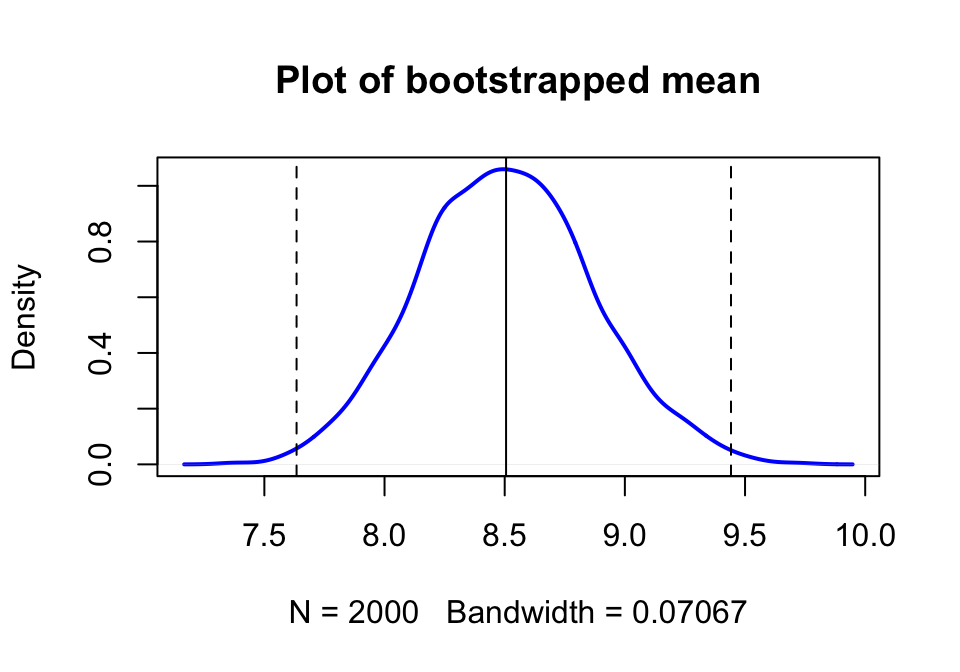

```r
plot(density(mean_boots), col="blue", main="Plot of bootstrapped mean", lwd=2)
abline(v=mean(mean_boots))
abline(v=pop_mean_ci_99, lty="dashed")
```

- 2. Bootstrapped difference between the population mean and the hypothesized mean

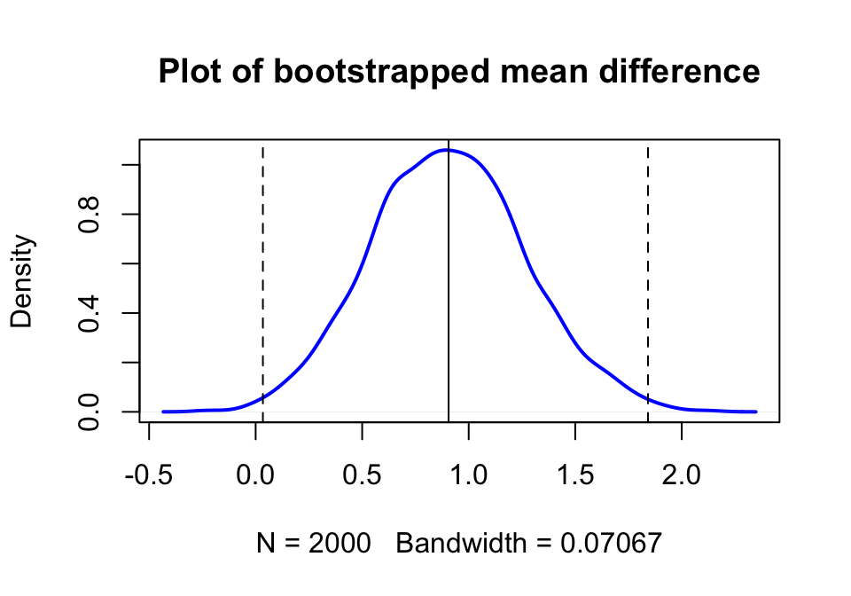

```r
plot(density(mean_diffs_boots), col="blue", main="Plot of bootstrapped mean difference", lwd=2)
abline(v=mean(mean_diffs_boots))
abline(v=diff_ci_99, lty="dashed")
```

- 3. Bootstrapped t-statistic

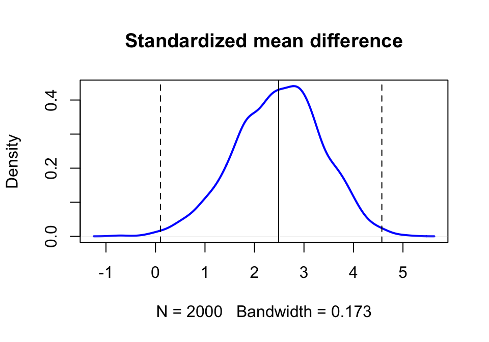

```r
plot(density(t_boots), col="blue", main="Standardized mean difference", lwd=2)
abline(v=mean(t_boots))
abline(v=t_ci_99, lty="dashed")
```

##### c. Do the four methods (traditional test, bootstrapped percentile, bootstrapped difference of means, bootstrapped t-Interval) agree with each other on the test?

- Answer: Yes, because the **shape** of plot in bootstrapped percentile, bootstrapped difference of means and bootstrapped t-Interval are the same. The only difference is the **scale**. Besides, the t-statistic(2.560762) is in the t_ci_99 and p(0.005265342) is smaller than 0.01.